# Final Report Outline

Joshua Harasaki, Tiffany Chiang, Katie Huynh

2/15/2022

## Introduction

The purpose of this project is to see if we can cluster customers based on demographic, behavioral, and lifestyle data.

## Overview of Data Set

This data is collected from a marketing campaign from an unspecified company.

Our data set includes data on customer demographic, amount spent on each type of product, campaign engagement, and where purchases were made.

Here is the link to our data set on kaggle:

https://www.kaggle.com/imakash3011/customer-personality-analysis

#### Types of Variables We Are Working With:

**People**

- ID: Customer’s unique identifier
- Year_Birth: Customer’s birth year
- Education: Customer’s education level
- Marital_Status: Customer’s marital status
- Income: Customer’s yearly household income
- Kidhome: Number of children in customer’s household
- Teenhome: Number of teenagers in customer’s household
- Dt_Customer: Date of customer’s enrollment with the company
- Recency: Number of days since customer’s last purchase
- Complain: 1 if the customer complained in the last 2 years, 0 otherwise

**Products**

- MntWines: Amount spent on wine in last 2 years
- MntFruits: Amount spent on fruits in last 2 years
- MntMeatProducts: Amount spent on meat in last 2 years
- MntFishProducts: Amount spent on fish in last 2 years
- MntSweetProducts: Amount spent on sweets in last 2 years
- MntGoldProds: Amount spent on gold in last 2 years

**Promotion**

- NumDealsPurchases: Number of purchases made with a discount
- AcceptedCmp1: 1 if customer accepted the offer in the 1st campaign, 0 otherwise
- AcceptedCmp2: 1 if customer accepted the offer in the 2nd campaign, 0 otherwise
- AcceptedCmp3: 1 if customer accepted the offer in the 3rd campaign, 0 otherwise
- AcceptedCmp4: 1 if customer accepted the offer in the 4th campaign, 0 otherwise
- AcceptedCmp5: 1 if customer accepted the offer in the 5th campaign, 0 otherwise
- Response: 1 if customer accepted the offer in the last campaign, 0 otherwise

**Place**

- NumWebPurchases: Number of purchases made through the company’s website
- NumCatalogPurchases: Number of purchases made using a catalogue
- NumStorePurchases: Number of purchases made directly in stores
- NumWebVisitsMonth: Number of visits to company’s website in the last month

```r
data = read.csv('data/unprocessed/marketing_campaign.csv', sep = '\t')  # load the data
head(data, 10)
```

```
##      ID Year_Birth  Education Marital_Status Income Kidhome Teenhome
## 1  5524       1957 Graduation         Single  58138       0        0
## 2  2174       1954 Graduation         Single  46344       1        1
## 3  4141       1965 Graduation       Together  71613       0        0
## 4  6182       1984 Graduation       Together  26646       1        0
## 5  5324       1981        PhD        Married  58293       1        0
## 6  7446       1967     Master       Together  62513       0        1
## 7   965       1971 Graduation       Divorced  55635       0        1
## 8  6177       1985        PhD        Married  33454       1        0
## 9  4855       1974        PhD       Together  30351       1        0
## 10 5899       1950        PhD       Together   5648       1        1
##    Dt_Customer Recency MntWines MntFruits MntMeatProducts MntFishProducts
## 1   04-09-2012      58      635        88             546             172
## 2   08-03-2014      38       11         1               6               2
## 3   21-08-2013      26      426        49             127             111
```

[output cut: 51 more lines]

## Data Cleaning & EDA

```r
count(data)
```

```
##      n
## 1 2240
```

There are 2240 rows in this dataset

```r
apply(is.na(data), 2, sum)
```

```
##                  ID          Year_Birth           Education      Marital_Status
##                   0                   0                   0                   0
##              Income             Kidhome            Teenhome         Dt_Customer
##                  24                   0                   0                   0
##             Recency            MntWines           MntFruits     MntMeatProducts
##                   0                   0                   0                   0
##     MntFishProducts    MntSweetProducts        MntGoldProds   NumDealsPurchases
##                   0                   0                   0                   0
##     NumWebPurchases NumCatalogPurchases   NumStorePurchases   NumWebVisitsMonth
##                   0                   0                   0                   0
##        AcceptedCmp3        AcceptedCmp4        AcceptedCmp5        AcceptedCmp1
##                   0                   0                   0                   0
##        AcceptedCmp2            Complain       Z_CostContact           Z_Revenue
##                   0                   0                   0                   0
##            Response
##                   0
```

From the output above, we see that the Income column contains 24 missing values. The rest of the columns contain no missing values.

Since 24 missing values is small compared to our total 2240 rows in our dataset, we are going to remove these rows that contain missing values.

```r
data <- data %>% filter(complete.cases(data))
head(data)
```

```
##     ID Year_Birth  Education Marital_Status Income Kidhome Teenhome Dt_Customer
## 1 5524       1957 Graduation         Single  58138       0        0  04-09-2012
## 2 2174       1954 Graduation         Single  46344       1        1  08-03-2014
## 3 4141       1965 Graduation       Together  71613       0        0  21-08-2013
## 4 6182       1984 Graduation       Together  26646       1        0  10-02-2014
## 5 5324       1981        PhD        Married  58293       1        0  19-01-2014
## 6 7446       1967     Master       Together  62513       0        1  09-09-2013
##   Recency MntWines MntFruits MntMeatProducts MntFishProducts MntSweetProducts
## 1      58      635        88             546             172               88
## 2      38       11         1               6               2                1
## 3      26      426        49             127             111               21
## 4      26       11         4              20              10                3
## 5      94      173        43             118              46               27
## 6      16      520        42              98               0               42
##   MntGoldProds NumDealsPurchases NumWebPurchases NumCatalogPurchases
```

[output cut: 20 more lines]

```r
count(data)
```

```
##      n
## 1 2216
```

Now, we have 2216 observations in our dataset.

### Now let’s explore each segment of the dataset

#### People

We want to be able to find the unique values in each of the categorical features in our dataset.

Here is the total count of each category under “Education”.

```r
count(data, data["Education"], sort = TRUE)
```

```
##    Education    n
## 1 Graduation 1116
## 2        PhD  481
## 3     Master  365
## 4   2n Cycle  200
## 5      Basic   54
```

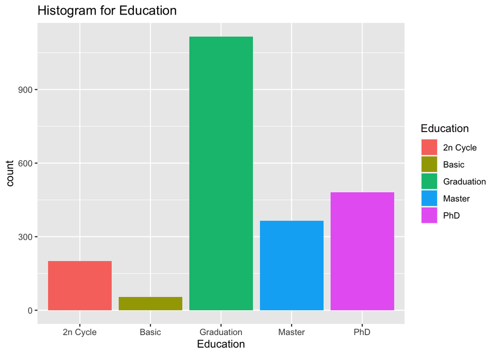

```r
ggplot(data, aes(Education, fill = Education)) +
  labs(title = 'Histogram for Education') +
  geom_bar()
```

Let’s simplify Education by creating only 3 unique values in this column.

```r
# convert "2n Cycle" and "Basic" to "Undergraduate"
data["Education"][data["Education"] == "2n Cycle" |
                    data["Education"] == "Basic"] <- "Undergraduate"
# convert "Graduation" to "Graduate"
data["Education"][data["Education"] == "Graduation"] <- "Graduate"
# convert "Master" and PhD to "Postgrad"
data["Education"][data["Education"] == "Master" | data["Education"] == "PhD"] <- "Postgrad"
# print new counts for Marital_Status column
count(data, data["Education"], sort = TRUE)
```

```
##       Education    n
## 1      Graduate 1116
## 2      Postgrad  846
## 3 Undergraduate  254
```

Let’s count the number of observations per category in “Martial_Status” as well.

```r
count(data, data["Marital_Status"], sort = TRUE)
```

```
##   Marital_Status   n
## 1        Married 857
## 2       Together 573
## 3         Single 471
## 4       Divorced 232
## 5          Widow  76
## 6          Alone   3
## 7         Absurd   2
## 8           YOLO   2
```

Since “Absurd” and “YOLO” aren’t useful to us under this feature, we are going to remove these rows.

```r
data <- data[!(data$Marital_Status == "YOLO" | data$Marital_Status == "Absurd"),]
head(data)
```

```
##     ID Year_Birth Education Marital_Status Income Kidhome Teenhome Dt_Customer
## 1 5524       1957  Graduate         Single  58138       0        0  04-09-2012
## 2 2174       1954  Graduate         Single  46344       1        1  08-03-2014
## 3 4141       1965  Graduate       Together  71613       0        0  21-08-2013
## 4 6182       1984  Graduate       Together  26646       1        0  10-02-2014
## 5 5324       1981  Postgrad        Married  58293       1        0  19-01-2014
## 6 7446       1967  Postgrad       Together  62513       0        1  09-09-2013
##   Recency MntWines MntFruits MntMeatProducts MntFishProducts MntSweetProducts
## 1      58      635        88             546             172               88
## 2      38       11         1               6               2                1
## 3      26      426        49             127             111               21
## 4      26       11         4              20              10                3
## 5      94      173        43             118              46               27
## 6      16      520        42              98               0               42
##   MntGoldProds NumDealsPurchases NumWebPurchases NumCatalogPurchases
```

[output cut: 20 more lines]

Let’s create two unique elements in Marital_Status

```r
# convert "Together" to "Married"
data["Marital_Status"][data["Marital_Status"] == "Together"] <- "Married"
# convert "Alone", "Divorced", and "Widow" to "Single"
data["Marital_Status"][data["Marital_Status"] == "Alone" |
                         data["Marital_Status"] == "Divorced" |
                         data["Marital_Status"] == "Widow"] <- "Single"
# print new counts for Marital_Status column
count(data, data["Marital_Status"], sort = TRUE)
```

```
##   Marital_Status    n
## 1        Married 1430
## 2         Single  782
```

When were our customer’s born?

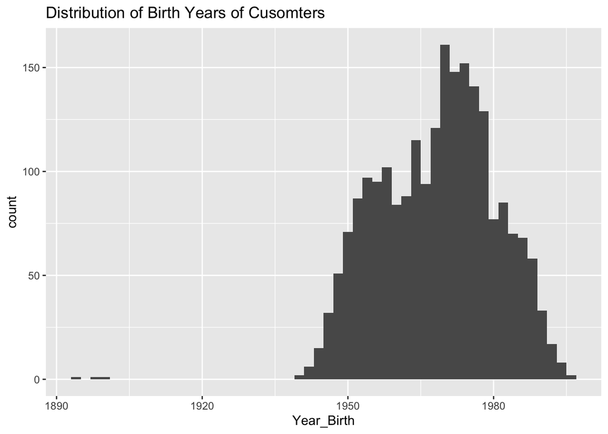

```r
ggplot(data, aes(Year_Birth)) +
  labs(title = 'Distribution of Birth Years of Cusomters') +
  geom_histogram(binwidth = 2)
```

```r
sprintf("Oldest Birth Year: %s", min(data$Year_Birth))
```

```
## [1] "Oldest Birth Year: 1893"
```

```r
sprintf("Latest Birth Year: %s", max(data$Year_Birth))
```

```
## [1] "Latest Birth Year: 1996"
```

```r
# identifies the rows that contain the outliers for Year_Birth
data[data$Year_Birth < 1920,]
```

```
##        ID Year_Birth     Education Marital_Status Income Kidhome Teenhome
## 182  7829       1900 Undergraduate         Single  36640       1        0
## 229 11004       1893 Undergraduate         Single  60182       0        1
## 327  1150       1899      Postgrad        Married  83532       0        0
##     Dt_Customer Recency MntWines MntFruits MntMeatProducts MntFishProducts
## 182  26-09-2013      99       15         6               8               7
## 229  17-05-2014      23        8         0               5               7
## 327  26-09-2013      36      755       144             562             104
##     MntSweetProducts MntGoldProds NumDealsPurchases NumWebPurchases
## 182                4           25                 1               2
## 229                0            2                 1               1
## 327               64          224                 1               4
##     NumCatalogPurchases NumStorePurchases NumWebVisitsMonth AcceptedCmp3
## 182                   1                 2                 5            0
## 229                   0                 2                 4            0
## 327                   6                 4                 1            0
##     AcceptedCmp4 AcceptedCmp5 AcceptedCmp1 AcceptedCmp2 Complain Z_CostContact
## 182            0            0            0            0        1             3
## 229            0            0            0            0        0             3
## 327            0            1            0            0        0             3
##     Z_Revenue Response
## 182        11        0
## 229        11        0
## 327        11        0
```

Let’s remove these outliers.

```r
data <- data[!(data$Year_Birth < 1920),]
head(data)
```

```
##     ID Year_Birth Education Marital_Status Income Kidhome Teenhome Dt_Customer
## 1 5524       1957  Graduate         Single  58138       0        0  04-09-2012
## 2 2174       1954  Graduate         Single  46344       1        1  08-03-2014
## 3 4141       1965  Graduate        Married  71613       0        0  21-08-2013
## 4 6182       1984  Graduate        Married  26646       1        0  10-02-2014
## 5 5324       1981  Postgrad        Married  58293       1        0  19-01-2014
## 6 7446       1967  Postgrad        Married  62513       0        1  09-09-2013
##   Recency MntWines MntFruits MntMeatProducts MntFishProducts MntSweetProducts
## 1      58      635        88             546             172               88
## 2      38       11         1               6               2                1
## 3      26      426        49             127             111               21
## 4      26       11         4              20              10                3
## 5      94      173        43             118              46               27
## 6      16      520        42              98               0               42
##   MntGoldProds NumDealsPurchases NumWebPurchases NumCatalogPurchases
```

[output cut: 20 more lines]

The dataset contains 2209 rows now.

#### More Feature Engineering

```r
# Create column for total spending
data["Total_Spending"] <- data["MntWines"] + data["MntFruits"] + data["MntMeatProducts"] +
                          data["MntFishProducts"] + data["MntSweetProducts"] +
                          data["MntGoldProds"]
head(data)
```

```
##     ID Year_Birth Education Marital_Status Income Kidhome Teenhome Dt_Customer
## 1 5524       1957  Graduate         Single  58138       0        0  04-09-2012
## 2 2174       1954  Graduate         Single  46344       1        1  08-03-2014
## 3 4141       1965  Graduate        Married  71613       0        0  21-08-2013
## 4 6182       1984  Graduate        Married  26646       1        0  10-02-2014
## 5 5324       1981  Postgrad        Married  58293       1        0  19-01-2014
## 6 7446       1967  Postgrad        Married  62513       0        1  09-09-2013
##   Recency MntWines MntFruits MntMeatProducts MntFishProducts MntSweetProducts
## 1      58      635        88             546             172               88
## 2      38       11         1               6               2                1
## 3      26      426        49             127             111               21
## 4      26       11         4              20              10                3
## 5      94      173        43             118              46               27
## 6      16      520        42              98               0               42
##   MntGoldProds NumDealsPurchases NumWebPurchases NumCatalogPurchases
```

[output cut: 27 more lines]

Remove the individual columns for amount spent on each product.

```r
del_amts <- c("MntWines", "MntFruits", "MntMeatProducts", "MntFishProducts",
              "MntSweetProducts", "MntGoldProds")
data <- data[,!(names(data) %in% del_amts)]
head(data)
```

```
##     ID Year_Birth Education Marital_Status Income Kidhome Teenhome Dt_Customer
## 1 5524       1957  Graduate         Single  58138       0        0  04-09-2012
## 2 2174       1954  Graduate         Single  46344       1        1  08-03-2014
## 3 4141       1965  Graduate        Married  71613       0        0  21-08-2013
## 4 6182       1984  Graduate        Married  26646       1        0  10-02-2014
## 5 5324       1981  Postgrad        Married  58293       1        0  19-01-2014
## 6 7446       1967  Postgrad        Married  62513       0        1  09-09-2013
##   Recency NumDealsPurchases NumWebPurchases NumCatalogPurchases
## 1      58                 3               8                  10
## 2      38                 2               1                   1
## 3      26                 1               8                   2
## 4      26                 2               2                   0
## 5      94                 5               5                   3
## 6      16                 2               6                   4
##   NumStorePurchases NumWebVisitsMonth AcceptedCmp3 AcceptedCmp4 AcceptedCmp5
```

[output cut: 20 more lines]

Create age column from Year_Birth. Here we are assuming that we got this data from the year 2018.

```r
data["Age"] <- 2018 - data["Year_Birth"]
data <- data[,!(names(data) == "Year_Birth")]
head(data)
```

```
##     ID Education Marital_Status Income Kidhome Teenhome Dt_Customer Recency
## 1 5524  Graduate         Single  58138       0        0  04-09-2012      58
## 2 2174  Graduate         Single  46344       1        1  08-03-2014      38
## 3 4141  Graduate        Married  71613       0        0  21-08-2013      26
## 4 6182  Graduate        Married  26646       1        0  10-02-2014      26
## 5 5324  Postgrad        Married  58293       1        0  19-01-2014      94
## 6 7446  Postgrad        Married  62513       0        1  09-09-2013      16
##   NumDealsPurchases NumWebPurchases NumCatalogPurchases NumStorePurchases
## 1                 3               8                  10                 4
## 2                 2               1                   1                 2
## 3                 1               8                   2                10
## 4                 2               2                   0                 4
## 5                 5               5                   3                 6
## 6                 2               6                   4                10
##   NumWebVisitsMonth AcceptedCmp3 AcceptedCmp4 AcceptedCmp5 AcceptedCmp1
## 1                 7            0            0            0            0
## 2                 5            0            0            0            0
## 3                 4            0            0            0            0
## 4                 6            0            0            0            0
## 5                 5            0            0            0            0
## 6                 6            0            0            0            0
##   AcceptedCmp2 Complain Z_CostContact Z_Revenue Response Total_Spending Age
## 1            0        0             3        11        1           1617  61
## 2            0        0             3        11        0             27  64
## 3            0        0             3        11        0            776  53
## 4            0        0             3        11        0             53  34
## 5            0        0             3        11        0            422  37
## 6            0        0             3        11        0            716  51
```

Replace the “KidHome” and “Teenhome” columns with a column representing the total number of children at home.

```r
data["Children"] <- data["Kidhome"] + data["Teenhome"]
data <- data[,!(names(data) == "Kidhome" | names(data) == "Teenhome")]
head(data)
```

```
##     ID Education Marital_Status Income Dt_Customer Recency NumDealsPurchases
## 1 5524  Graduate         Single  58138  04-09-2012      58                 3
## 2 2174  Graduate         Single  46344  08-03-2014      38                 2
## 3 4141  Graduate        Married  71613  21-08-2013      26                 1
## 4 6182  Graduate        Married  26646  10-02-2014      26                 2
## 5 5324  Postgrad        Married  58293  19-01-2014      94                 5
## 6 7446  Postgrad        Married  62513  09-09-2013      16                 2
##   NumWebPurchases NumCatalogPurchases NumStorePurchases NumWebVisitsMonth
## 1               8                  10                 4                 7
## 2               1                   1                 2                 5
## 3               8                   2                10                 4
## 4               2                   0                 4                 6
## 5               5                   3                 6                 5
## 6               6                   4                10                 6
##   AcceptedCmp3 AcceptedCmp4 AcceptedCmp5 AcceptedCmp1 AcceptedCmp2 Complain
## 1            0            0            0            0            0        0
## 2            0            0            0            0            0        0
## 3            0            0            0            0            0        0
## 4            0            0            0            0            0        0
## 5            0            0            0            0            0        0
## 6            0            0            0            0            0        0
##   Z_CostContact Z_Revenue Response Total_Spending Age Children
## 1             3        11        1           1617  61        0
## 2             3        11        0             27  64        2
## 3             3        11        0            776  53        0
## 4             3        11        0             53  34        1
## 5             3        11        0            422  37        1
## 6             3        11        0            716  51        1
```

Create a column for the total number of purchases.

```r
data["TotalNumPurchases"] <- data["NumWebPurchases"] + data["NumCatalogPurchases"] +
                            data["NumStorePurchases"] + data["NumDealsPurchases"]
del_NumPurchases <- c("NumWebPurchases", "NumCatalogPurchases", "NumStorePurchases",
                      "NumDealsPurchases")
data <- data[,!(names(data) %in% del_NumPurchases)]
head(data)
```

```
##     ID Education Marital_Status Income Dt_Customer Recency NumWebVisitsMonth
## 1 5524  Graduate         Single  58138  04-09-2012      58                 7
## 2 2174  Graduate         Single  46344  08-03-2014      38                 5
## 3 4141  Graduate        Married  71613  21-08-2013      26                 4
## 4 6182  Graduate        Married  26646  10-02-2014      26                 6
## 5 5324  Postgrad        Married  58293  19-01-2014      94                 5
## 6 7446  Postgrad        Married  62513  09-09-2013      16                 6
##   AcceptedCmp3 AcceptedCmp4 AcceptedCmp5 AcceptedCmp1 AcceptedCmp2 Complain
## 1            0            0            0            0            0        0
## 2            0            0            0            0            0        0
## 3            0            0            0            0            0        0
## 4            0            0            0            0            0        0
## 5            0            0            0            0            0        0
## 6            0            0            0            0            0        0
##   Z_CostContact Z_Revenue Response Total_Spending Age Children
## 1             3        11        1           1617  61        0
## 2             3        11        0             27  64        2
## 3             3        11        0            776  53        0
## 4             3        11        0             53  34        1
## 5             3        11        0            422  37        1
## 6             3        11        0            716  51        1
##   TotalNumPurchases
## 1                25
## 2                 6
## 3                21
## 4                 8
## 5                19
## 6                22
```

```r
unique(data["Z_CostContact"])
```

```
##   Z_CostContact
## 1             3
```

```r
unique(data["Z_Revenue"])
```

```
##   Z_Revenue
## 1        11
```

Delete “Z_CostContact” and “Z_Revenue” because it only has one unique value.

```r
data <- data[,!(names(data) == "Z_CostContact" | names(data) == "Z_Revenue")]
head(data)
```

```
##     ID Education Marital_Status Income Dt_Customer Recency NumWebVisitsMonth
## 1 5524  Graduate         Single  58138  04-09-2012      58                 7
## 2 2174  Graduate         Single  46344  08-03-2014      38                 5
## 3 4141  Graduate        Married  71613  21-08-2013      26                 4
## 4 6182  Graduate        Married  26646  10-02-2014      26                 6
## 5 5324  Postgrad        Married  58293  19-01-2014      94                 5
## 6 7446  Postgrad        Married  62513  09-09-2013      16                 6
##   AcceptedCmp3 AcceptedCmp4 AcceptedCmp5 AcceptedCmp1 AcceptedCmp2 Complain
## 1            0            0            0            0            0        0
## 2            0            0            0            0            0        0
## 3            0            0            0            0            0        0
## 4            0            0            0            0            0        0
## 5            0            0            0            0            0        0
## 6            0            0            0            0            0        0
##   Response Total_Spending Age Children TotalNumPurchases
## 1        1           1617  61        0                25
## 2        0             27  64        2                 6
## 3        0            776  53        0                21
## 4        0             53  34        1                 8
## 5        0            422  37        1                19
## 6        0            716  51        1                22
```

Delete other unimportant columns for performing dimension reduction and clustering

```r
del_unimp <- c("ID", "Dt_Customer")
data <- data[,!(names(data) %in% del_unimp)]
head(data)
```

```
##   Education Marital_Status Income Recency NumWebVisitsMonth AcceptedCmp3
## 1  Graduate         Single  58138      58                 7            0
## 2  Graduate         Single  46344      38                 5            0
## 3  Graduate        Married  71613      26                 4            0
## 4  Graduate        Married  26646      26                 6            0
## 5  Postgrad        Married  58293      94                 5            0
## 6  Postgrad        Married  62513      16                 6            0
##   AcceptedCmp4 AcceptedCmp5 AcceptedCmp1 AcceptedCmp2 Complain Response
## 1            0            0            0            0        0        1
## 2            0            0            0            0        0        0
## 3            0            0            0            0        0        0
## 4            0            0            0            0        0        0
## 5            0            0            0            0        0        0
## 6            0            0            0            0        0        0
##   Total_Spending Age Children TotalNumPurchases
## 1           1617  61        0                25
## 2             27  64        2                 6
## 3            776  53        0                21
## 4             53  34        1                 8
## 5            422  37        1                19
## 6            716  51        1                22
```

Delete the complain column.

```r
data <- data[,!(names(data) == "Complain")]
```

Create a column for the total number of accepted promotions

```r
data["TotalAcceptedCmp"] <- data["AcceptedCmp1"] + data["AcceptedCmp2"] +
                            data["AcceptedCmp3"] + data["AcceptedCmp4"] +
                            data["AcceptedCmp5"] + data["Response"]
del_accep_cmp <- c("AcceptedCmp1", "AcceptedCmp2", "AcceptedCmp3", "AcceptedCmp4",
                   "AcceptedCmp5", "Response")
data <- data[,!(names(data) %in% del_accep_cmp)]
head(data)
```

```
##   Education Marital_Status Income Recency NumWebVisitsMonth Total_Spending Age
## 1  Graduate         Single  58138      58                 7           1617  61
## 2  Graduate         Single  46344      38                 5             27  64
## 3  Graduate        Married  71613      26                 4            776  53
## 4  Graduate        Married  26646      26                 6             53  34
## 5  Postgrad        Married  58293      94                 5            422  37
## 6  Postgrad        Married  62513      16                 6            716  51
##   Children TotalNumPurchases TotalAcceptedCmp
## 1        0                25                1
## 2        2                 6                0
## 3        0                21                0
## 4        1                 8                0
## 5        1                19                0
## 6        1                22                0
```